# Prosper Loan Data Analysis by Yuxun Ling

## Loading Dataset and Libraries

```
## 'data.frame':    113937 obs. of  81 variables:
##  $ ListingKey                         : Factor w/ 113066 levels "00003546482094282EF90E5",..: 7180 7193 6647 6669 6686 6689 6699 6706 6687 6687 ...
##  $ ListingNumber                      : int  193129 1209647 81716 658116 909464 1074836 750899 768193 1023355 1023355 ...
##  $ ListingCreationDate                : Factor w/ 113064 levels "2005-11-09 20:44:28.847000000",..: 14184 111894 6429 64760 85967 100310 72556 74019 97834 97834 ...
##  $ CreditGrade                        : Factor w/ 9 levels "","A","AA","B",..: 5 1 8 1 1 1 1 1 1 1 ...
##  $ Term                               : int  36 36 36 36 36 60 36 36 36 36 ...
##  $ LoanStatus                         : Factor w/ 12 levels "Cancelled","Chargedoff",..: 3 4 3 4 4 4 4 4 4 4 ...
##  $ ClosedDate                         : Factor w/ 2803 levels "","2005-11-25 00:00:00",..: 1138 1 1263 1 1 1 1 1 1 1 ...
##  $ BorrowerAPR                        : num  0.165 0.12 0.283 0.125 0.246 ...
##  $ BorrowerRate                       : num  0.158 0.092 0.275 0.0974 0.2085 ...
##  $ LenderYield                        : num  0.138 0.082 0.24 0.0874 0.1985 ...
##  $ EstimatedEffectiveYield            : num  NA 0.0796 NA 0.0849 0.1832 ...
##  $ EstimatedLoss                      : num  NA 0.0249 NA 0.0249 0.0925 ...
##  $ EstimatedReturn                    : num  NA 0.0547 NA 0.06 0.0907 ...
##  $ ProsperRating..numeric.            : int  NA 6 NA 6 3 5 2 4 7 7 ...
```

[output cut: 67 more lines]

## Some Basic Overviews on The Dateset

```
##  [1] "ListingKey"              "ListingCreationDate"
##  [3] "CreditGrade"             "LoanStatus"
##  [5] "ClosedDate"              "ProsperRating..Alpha."
##  [7] "BorrowerState"           "Occupation"
##  [9] "EmploymentStatus"        "IsBorrowerHomeowner"
## [11] "CurrentlyInGroup"        "GroupKey"
## [13] "DateCreditPulled"        "FirstRecordedCreditLine"
## [15] "IncomeRange"             "IncomeVerifiable"
## [17] "LoanKey"                 "LoanOriginationDate"
## [19] "LoanOriginationQuarter"  "MemberKey"
```

```r
#identify levels of factors
levels(data_o$CreditGrade)
```

```
## [1] ""   "A"  "AA" "B"  "C"  "D"  "E"  "HR" "NC"
```

```r
levels(data_o$LoanStatus)
```

```
##  [1] "Cancelled"              "Chargedoff"
##  [3] "Completed"              "Current"
##  [5] "Defaulted"              "FinalPaymentInProgress"
##  [7] "Past Due (>120 days)"   "Past Due (1-15 days)"
##  [9] "Past Due (16-30 days)"  "Past Due (31-60 days)"
## [11] "Past Due (61-90 days)"  "Past Due (91-120 days)"
```

```r
levels(data_o$ProsperRating..Alpha.)
```

```
## [1] ""   "A"  "AA" "B"  "C"  "D"  "E"  "HR"
```

```r
levels(data_o$BorrowerState)
```

```
##  [1] ""   "AK" "AL" "AR" "AZ" "CA" "CO" "CT" "DC" "DE" "FL" "GA" "HI" "IA"
## [15] "ID" "IL" "IN" "KS" "KY" "LA" "MA" "MD" "ME" "MI" "MN" "MO" "MS" "MT"
## [29] "NC" "ND" "NE" "NH" "NJ" "NM" "NV" "NY" "OH" "OK" "OR" "PA" "RI" "SC"
## [43] "SD" "TN" "TX" "UT" "VA" "VT" "WA" "WI" "WV" "WY"
```

```r
levels(data_o$Occupation)
```

```
##  [1] ""
##  [2] "Accountant/CPA"
##  [3] "Administrative Assistant"
##  [4] "Analyst"
##  [5] "Architect"
##  [6] "Attorney"
##  [7] "Biologist"
##  [8] "Bus Driver"
##  [9] "Car Dealer"
## [10] "Chemist"
## [11] "Civil Service"
## [12] "Clergy"
## [13] "Clerical"
## [14] "Computer Programmer"
## [15] "Construction"
```

[output cut: 53 more lines]

```r
levels(data_o$EmploymentStatus)
```

```
## [1] ""              "Employed"      "Full-time"     "Not available"
## [5] "Not employed"  "Other"         "Part-time"     "Retired"
## [9] "Self-employed"
```

```r
levels(data_o$IncomeRange)
```

```
## [1] "$0"             "$1-24,999"      "$100,000+"      "$25,000-49,999"
## [5] "$50,000-74,999" "$75,000-99,999" "Not displayed"  "Not employed"
```

```
##                    ListingKey     ListingNumber
##  17A93590655669644DB4C06:     6   Min.   :      4
##  349D3587495831350F0F648:     4   1st Qu.: 400919
##  47C1359638497431975670B:     4   Median : 600554
##  8474358854651984137201C:     4   Mean   : 627886
##  DE8535960513435199406CE:     4   3rd Qu.: 892634
##  04C13599434217079754AEE:     3   Max.   :1255725
##  (Other)                :113912
##                     ListingCreationDate  CreditGrade         Term
##  2013-10-02 17:20:16.550000000:     6          :84984   Min.   :12.00
##  2013-08-28 20:31:41.107000000:     4   C      : 5649   1st Qu.:36.00
##  2013-09-08 09:27:44.853000000:     4   D      : 5153   Median :36.00
##  2013-12-06 05:43:13.830000000:     4   B      : 4389   Mean   :40.83
##  2013-12-06 11:44:58.283000000:     4   AA     : 3509   3rd Qu.:36.00
##  2013-08-21 07:25:22.360000000:     3   HR     : 3508   Max.   :60.00
##  (Other)                      :113912   (Other): 6745
##                  LoanStatus                  ClosedDate
##  Current              :56576                      :58848
##  Completed            :38074   2014-03-04 00:00:00:  105
##  Chargedoff           :11992   2014-02-19 00:00:00:  100
##  Defaulted            : 5018   2014-02-11 00:00:00:   92
##  Past Due (1-15 days) :  806   2012-10-30 00:00:00:   81
##  Past Due (31-60 days):  363   2013-02-26 00:00:00:   78
##  (Other)              : 1108   (Other)            :54633
##   BorrowerAPR       BorrowerRate     LenderYield
##  Min.   :0.00653   Min.   :0.0000   Min.   :-0.0100
##  1st Qu.:0.15629   1st Qu.:0.1340   1st Qu.: 0.1242
##  Median :0.20976   Median :0.1840   Median : 0.1730
##  Mean   :0.21883   Mean   :0.1928   Mean   : 0.1827
##  3rd Qu.:0.28381   3rd Qu.:0.2500   3rd Qu.: 0.2400
##  Max.   :0.51229   Max.   :0.4975   Max.   : 0.4925
##  NA's   :25
##  EstimatedEffectiveYield EstimatedLoss   EstimatedReturn
##  Min.   :-0.183          Min.   :0.005   Min.   :-0.183
##  1st Qu.: 0.116          1st Qu.:0.042   1st Qu.: 0.074
##  Median : 0.162          Median :0.072   Median : 0.092
##  Mean   : 0.169          Mean   :0.080   Mean   : 0.096
##  3rd Qu.: 0.224          3rd Qu.:0.112   3rd Qu.: 0.117
##  Max.   : 0.320          Max.   :0.366   Max.   : 0.284
##  NA's   :29084           NA's   :29084   NA's   :29084
```

[output cut: 193 more lines]

```
##  Min.   :    0.00                Min.   :0.7000   Min.   : 0.00000
##  1st Qu.:    0.00                1st Qu.:1.0000   1st Qu.: 0.00000
##  Median :    0.00                Median :1.0000   Median : 0.00000
##  Mean   :   25.14                Mean   :0.9986   Mean   : 0.04803
##  3rd Qu.:    0.00                3rd Qu.:1.0000   3rd Qu.: 0.00000
##  Max.   :21117.90                Max.   :1.0125   Max.   :39.00000
##
##  InvestmentFromFriendsCount InvestmentFromFriendsAmount   Investors
##  Min.   : 0.00000           Min.   :    0.00            Min.   :   1.00
##  1st Qu.: 0.00000           1st Qu.:    0.00            1st Qu.:   2.00
##  Median : 0.00000           Median :    0.00            Median :  44.00
##  Mean   : 0.02346           Mean   :   16.55            Mean   :  80.48
##  3rd Qu.: 0.00000           3rd Qu.:    0.00            3rd Qu.: 115.00
##  Max.   :33.00000           Max.   :25000.00            Max.   :1189.00
##
```

The summary indicates that ListingKey, ListingCreationDate, LoanKey, and DateCreditPulled are related

ProsperRating and ProsperScore related to EstimatedEffectiveYield, EstimatedLoss, and EstimatedRetuen. (because they have same amount of NA’s)

Over 2/3 of the total observations do not have CreditGrade

Some variables related to delinquencies have skewed obervations.

## Univariante Graphs and Basic Analysis

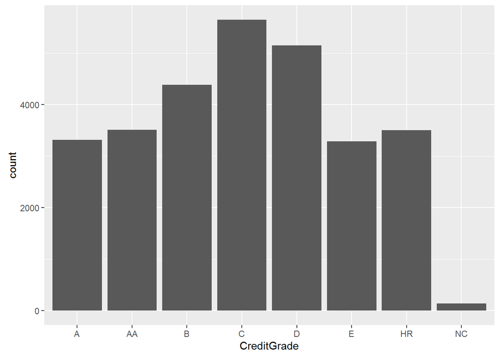

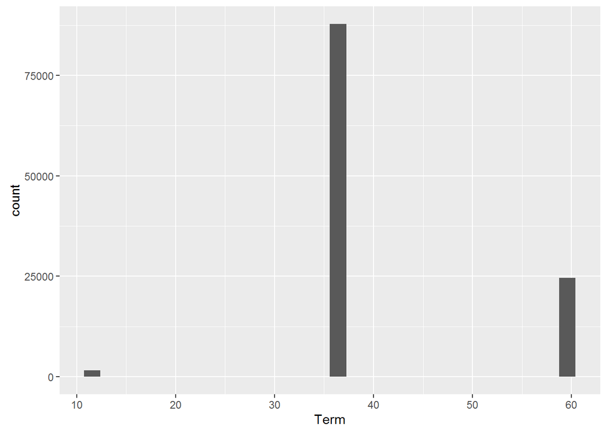

Only Three Possible Terms are allowed. (One year, Three years, and five years)

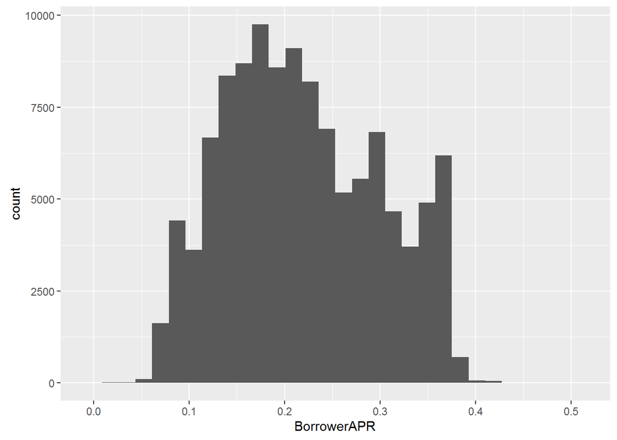

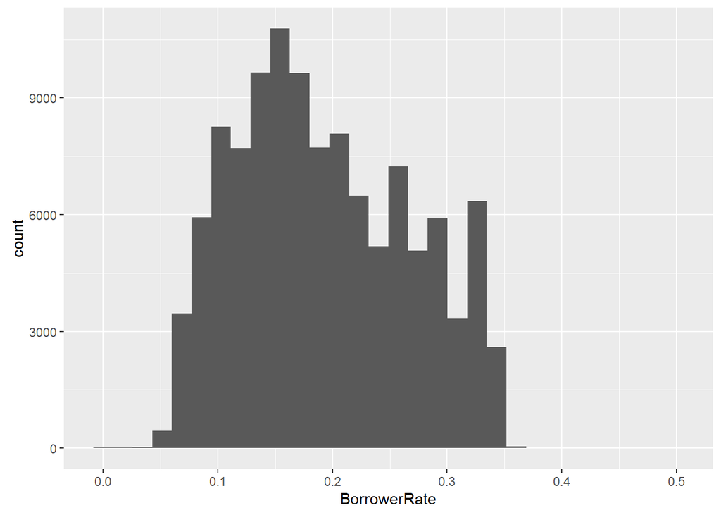

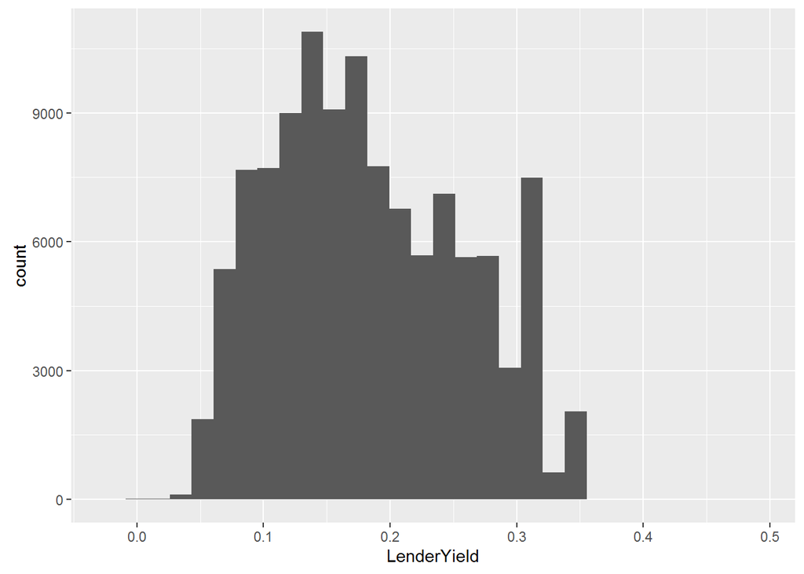

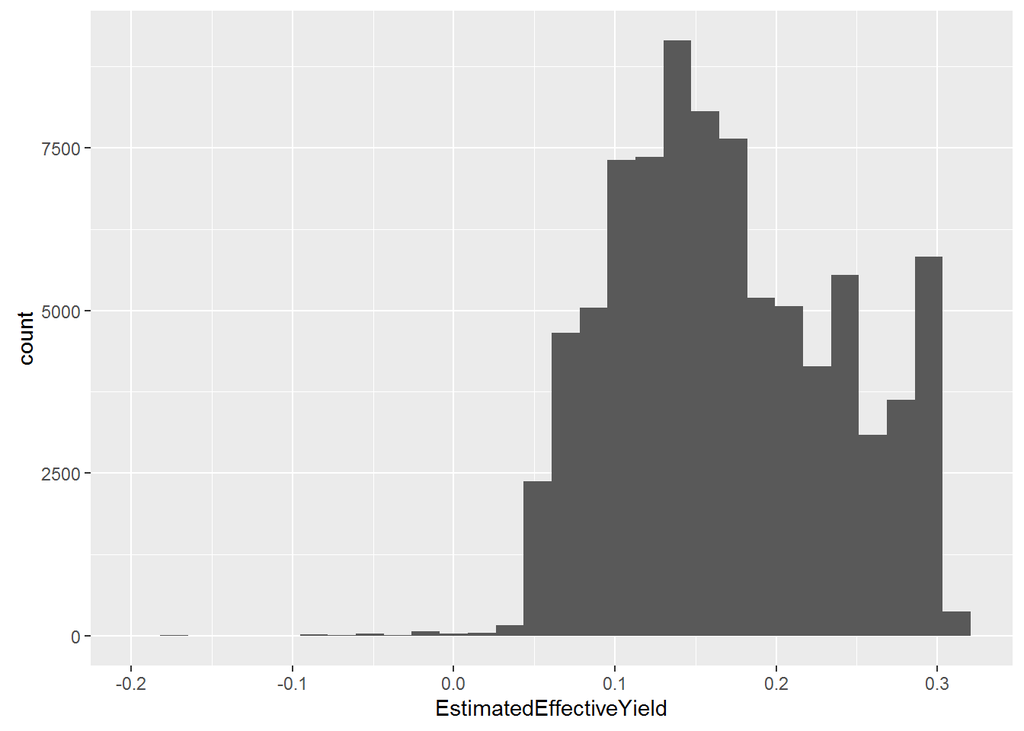

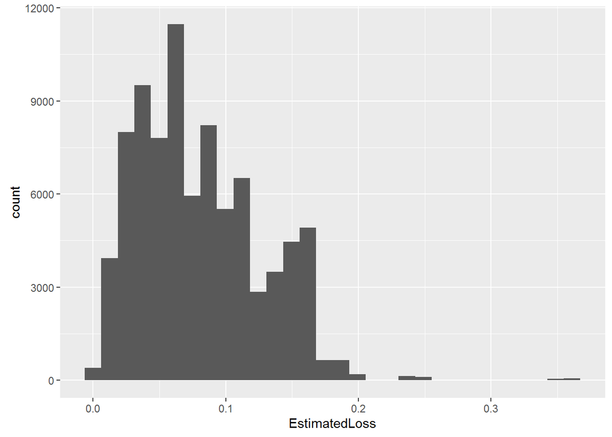

```
##
##  Pearson's product-moment correlation
##
## data:  data_o$BorrowerAPR and data_o$BorrowerRate
## t = 2347.7, df = 113910, p-value < 2.2e-16
## alternative hypothesis: true correlation is not equal to 0
## 95 percent confidence interval:
##  0.9897057 0.9899409
## sample estimates:
##      cor
## 0.989824
```

[output not shown]

```
##
##  Pearson's product-moment correlation
##
## data:  data_o$EstimatedEffectiveYield and data_o$BorrowerRate
## t = 585.39, df = 84851, p-value < 2.2e-16
## alternative hypothesis: true correlation is not equal to 0
## 95 percent confidence interval:
##  0.8939390 0.8966099
## sample estimates:
##       cor
## 0.8952825
```

```
##
##  Pearson's product-moment correlation
##
## data:  data_o$EstimatedLoss and data_o$BorrowerRate
## t = 844.11, df = 84851, p-value < 2.2e-16
## alternative hypothesis: true correlation is not equal to 0
## 95 percent confidence interval:
##  0.9445764 0.9460085
## sample estimates:
##      cor
## 0.945297
```

The pearson correlation test also suggests strong correlation between BorrowerRate and other four variables.

The correlation between EstimateedEffectiveYield and BorrowerRate is 0.5% less than 0.9 may due to the involving of late fee and charge-off loss.

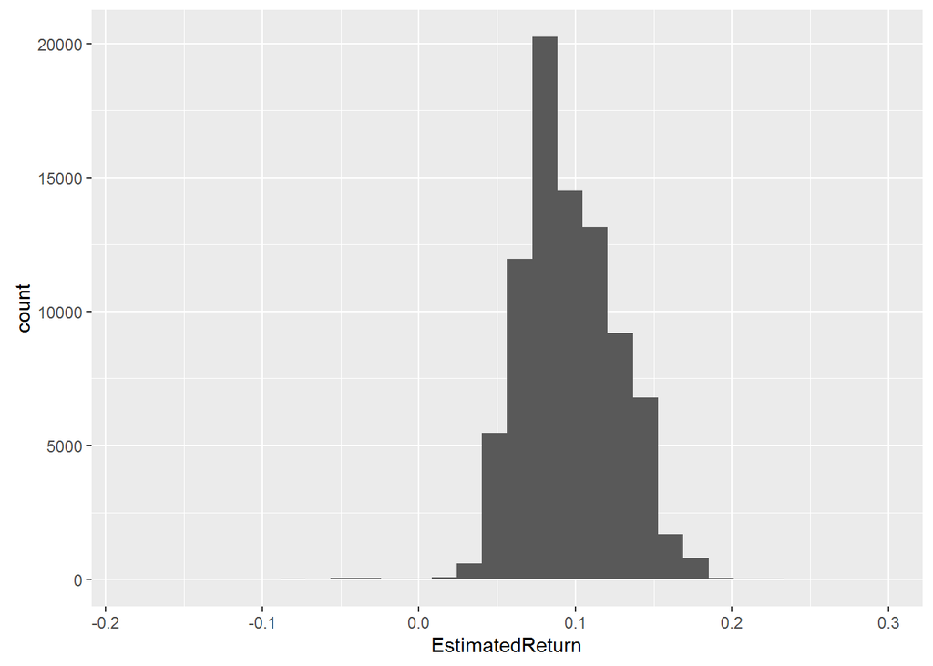

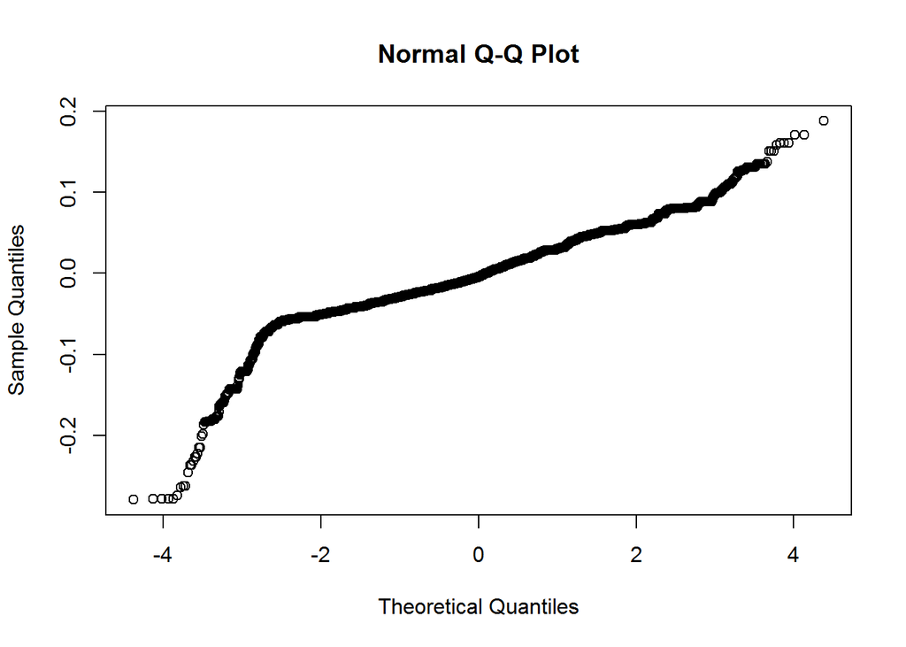

EstimatedReturn is not symmetrically distributed around mean.

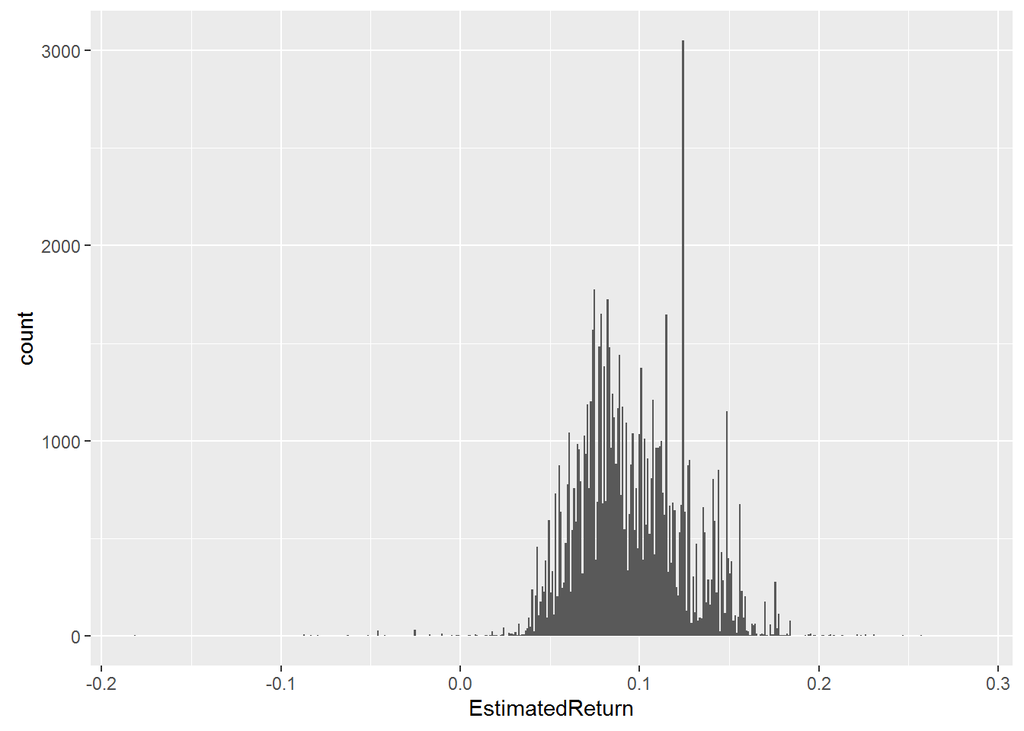

```
## Source: local data frame [6 x 2]
##
##   EstimatedReturn     n
##             (dbl) (int)
## 1          0.1246  2217
## 2          0.1487  1097
## 3          0.0691   760
## 4          0.1414   738
## 5          0.1074   654
## 6          0.1150   611
```

A closer look indicates that some specific values (e.g. 0.1246) have extremely high count.

```
## Source: local data frame [6 x 2]
##
##   BorrowerRate     n
##          (dbl) (int)
## 1       0.3177  3672
## 2       0.3500  1905
## 3       0.3199  1651
## 4       0.2900  1508
## 5       0.2699  1319
## 6       0.1500  1182
```

Counting the frequency of each value of BorrowerRate. One possibile cause of high-count EstimateReturn may be a high count of BorrowerRate at 0.3177.

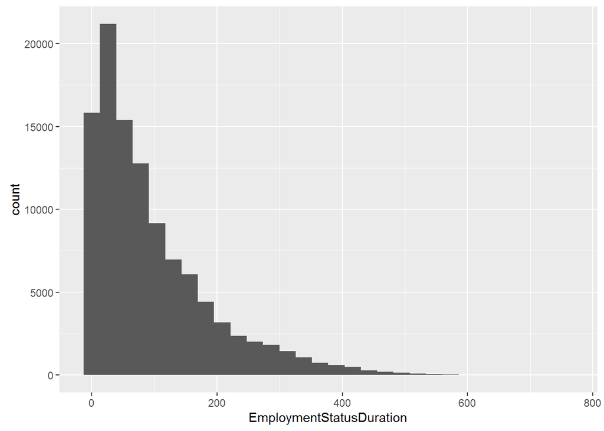

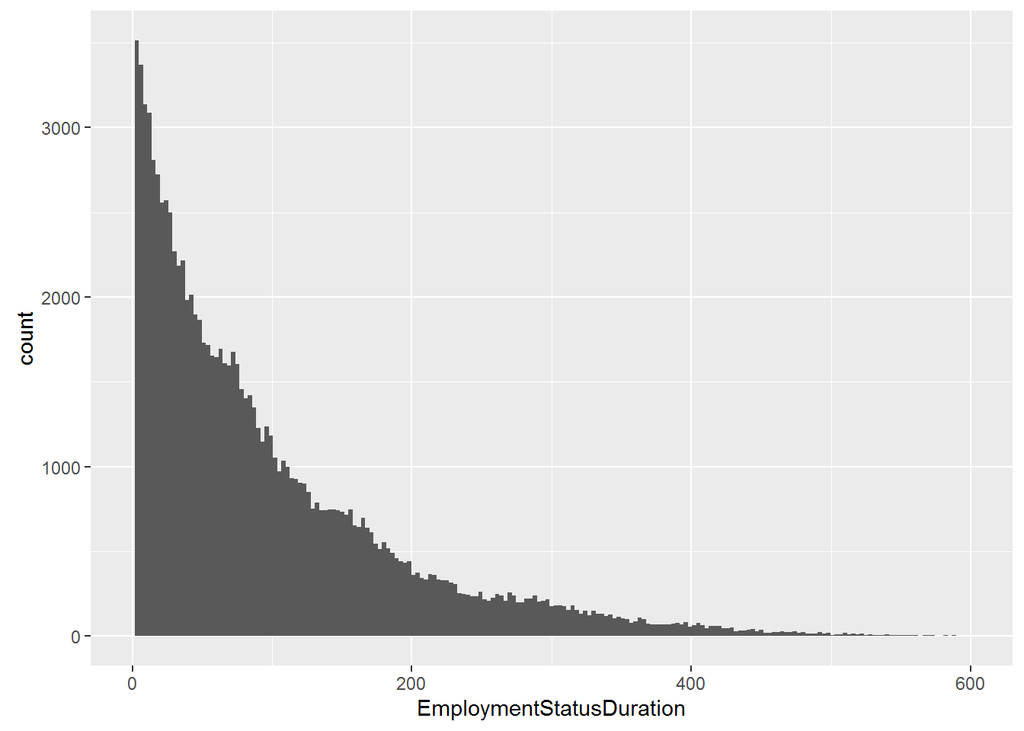

Notice that in average, people with longer employment duration are less likely to borrow.

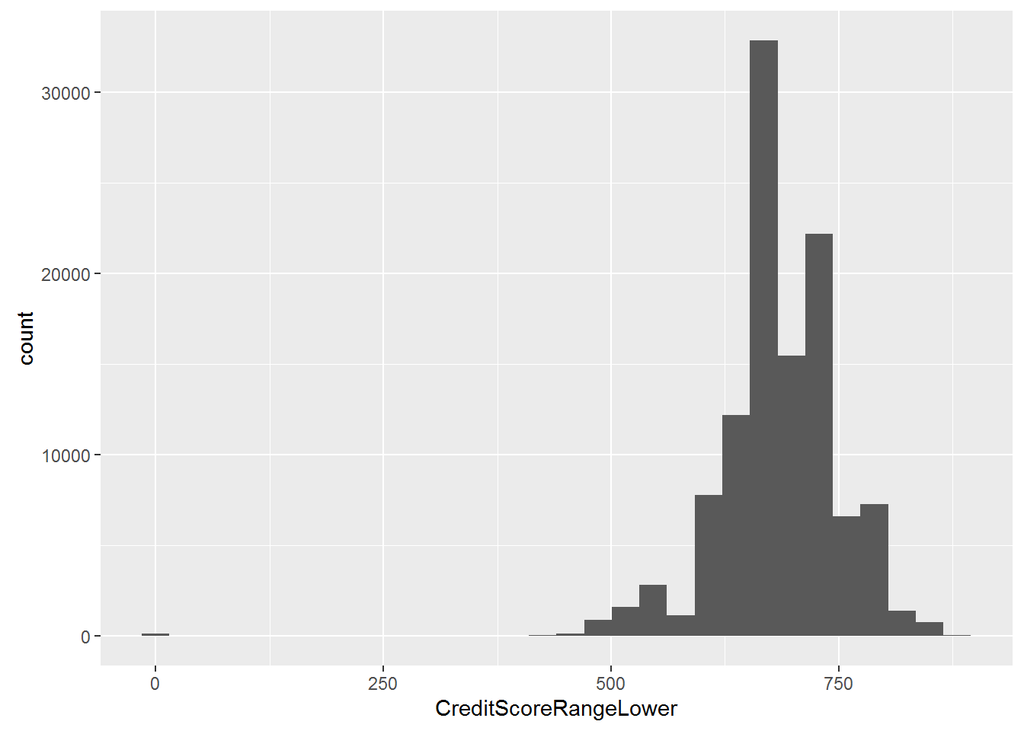

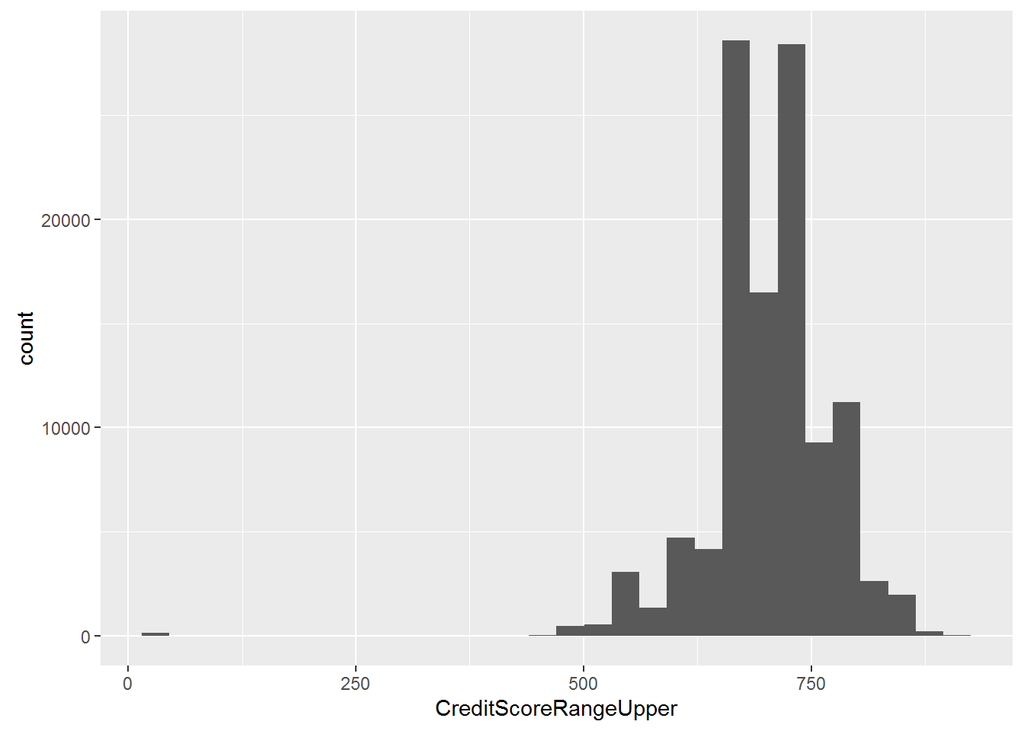

```
##
##  Pearson's product-moment correlation
##
## data:  CreditScoreRangeLower and CreditScoreRangeUpper
## t = 1.5976e+10, df = 113340, p-value < 2.2e-16
## alternative hypothesis: true correlation is not equal to 0
## 95 percent confidence interval:
##  1 1
## sample estimates:
## cor
##   1
```

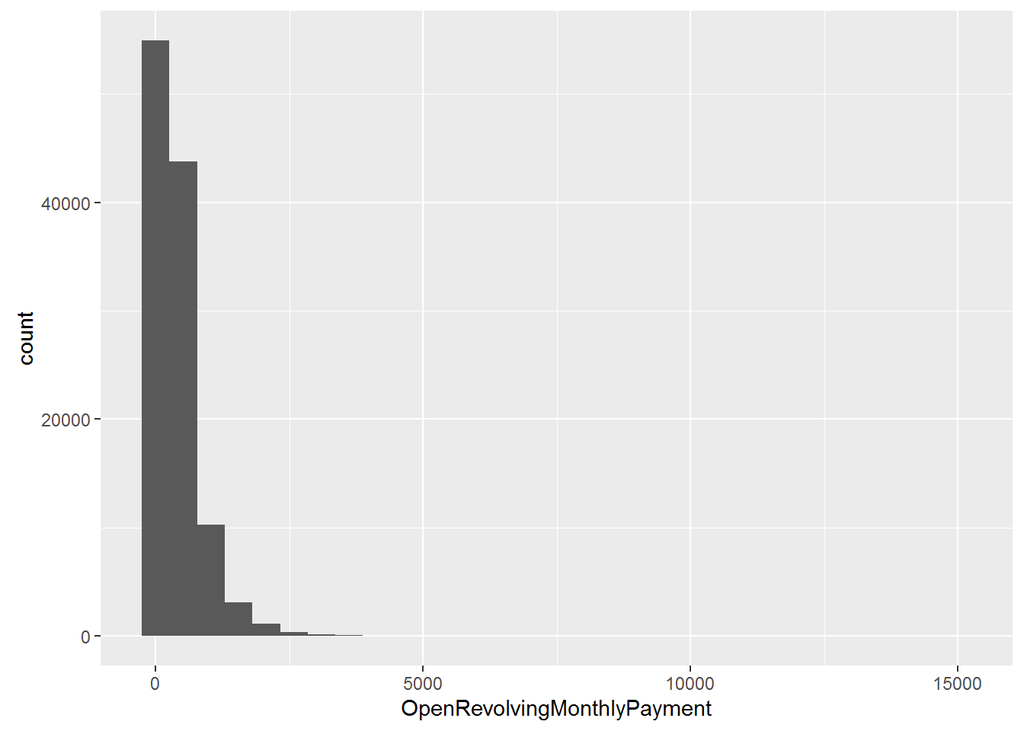

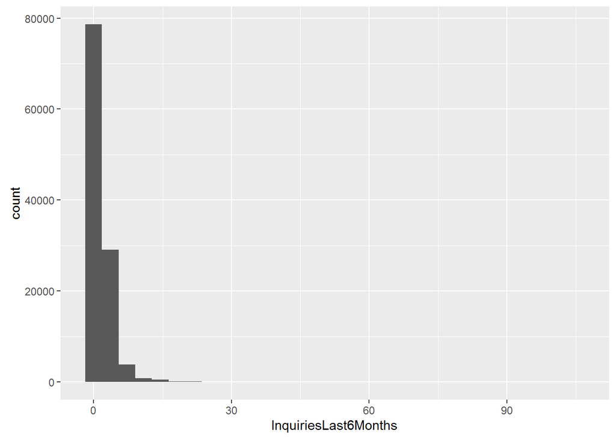

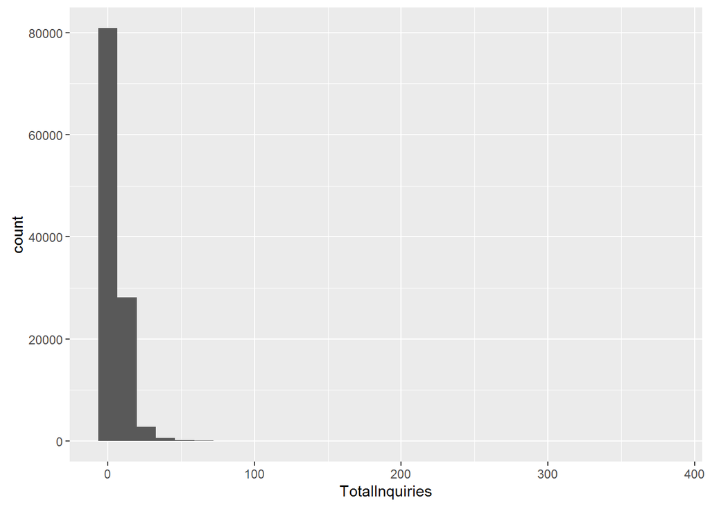

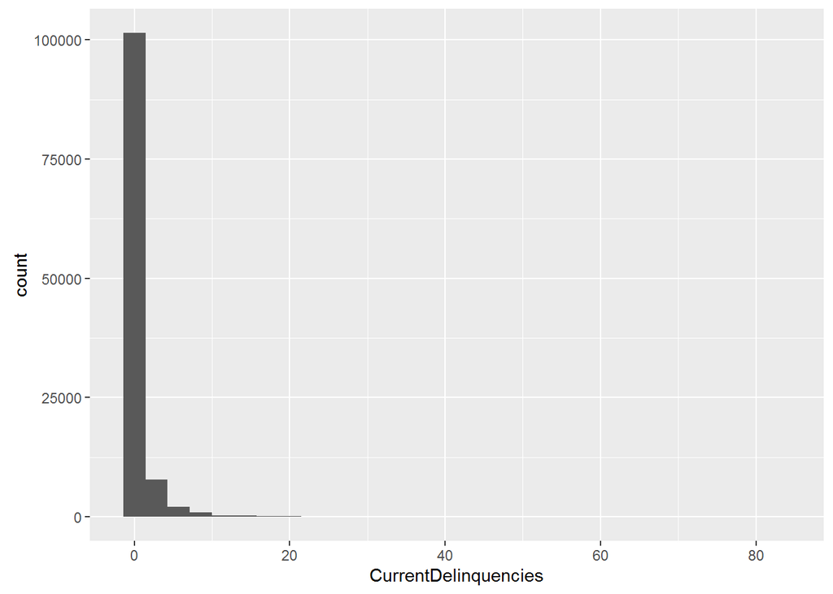

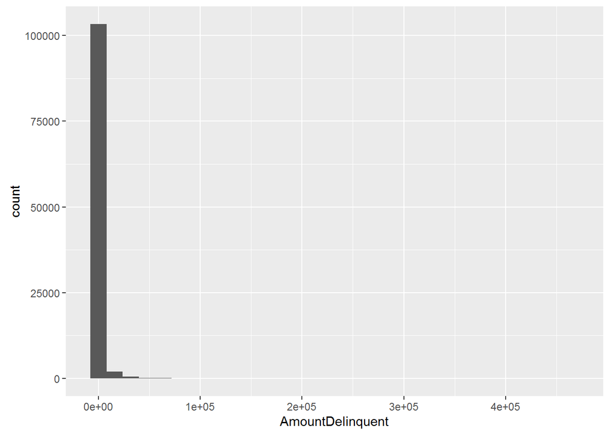

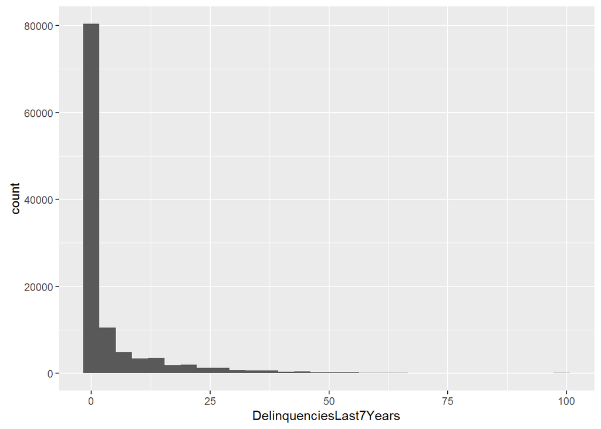

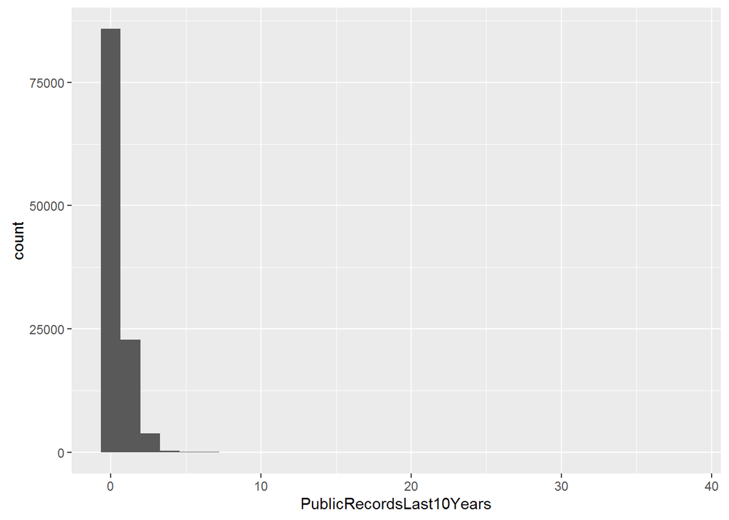

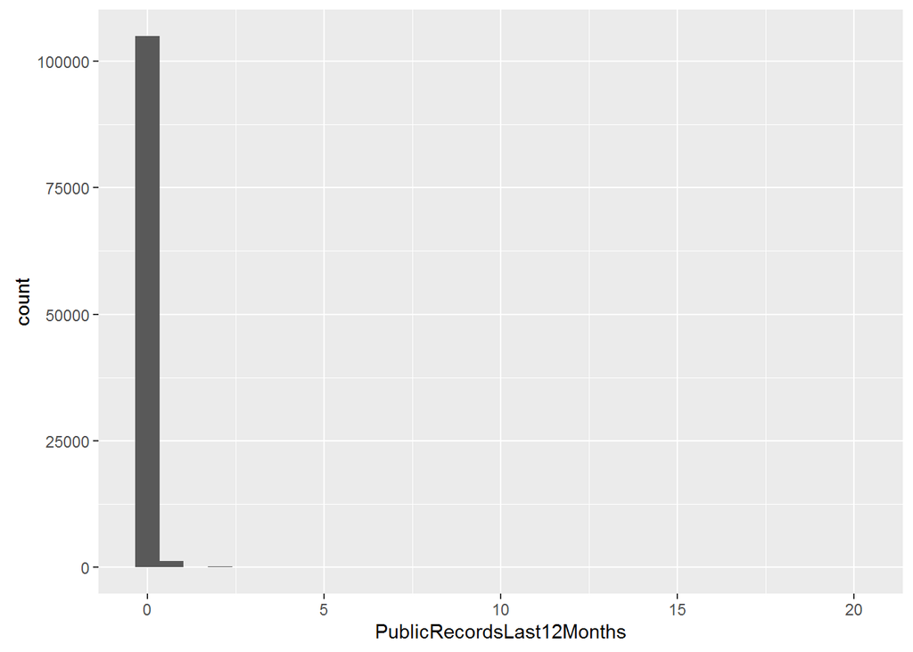

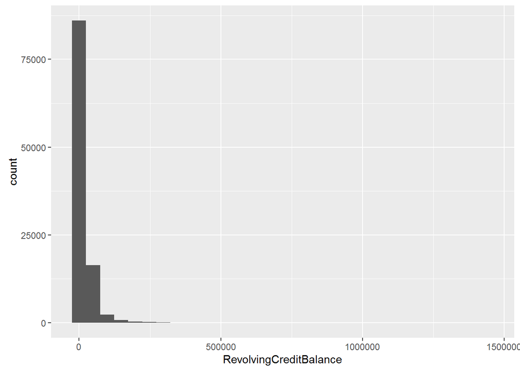

Above nine graphs have extremely high count near zero, and extremely high value with low counts, and thus may not be useful on their own.

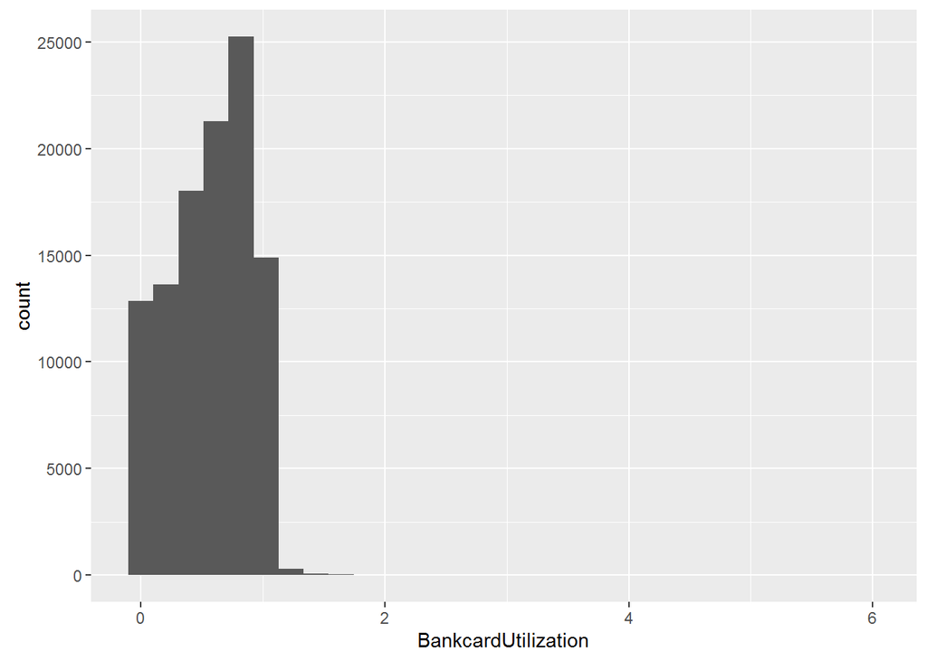

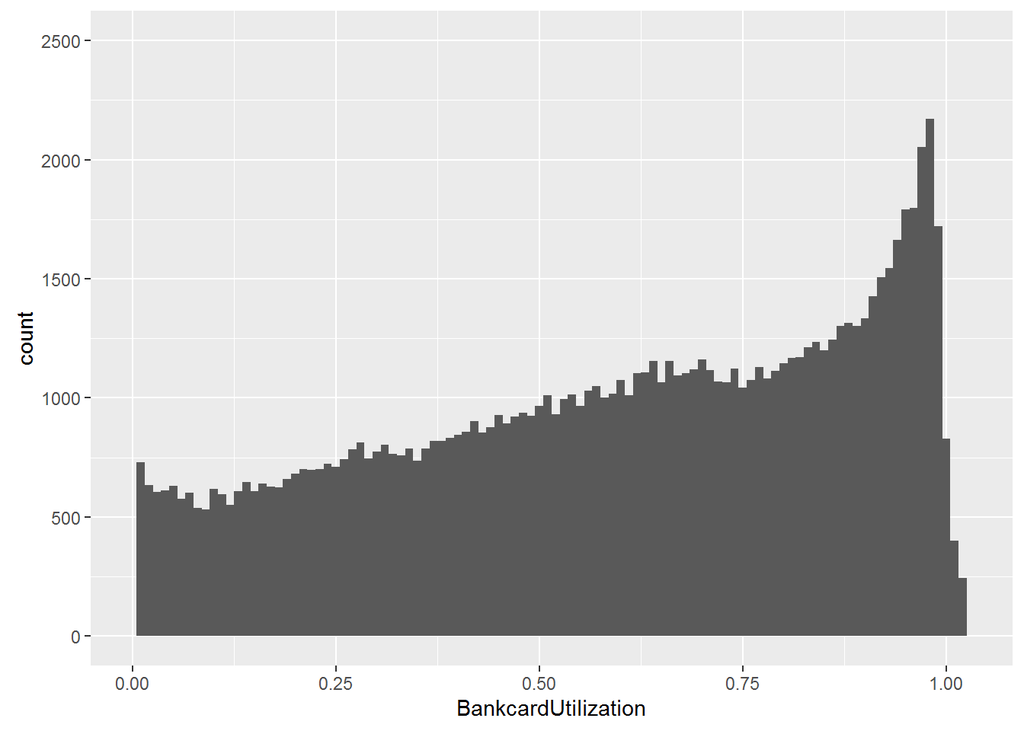

about 1% out of all borrower have BantcardUtilization greater than 1.

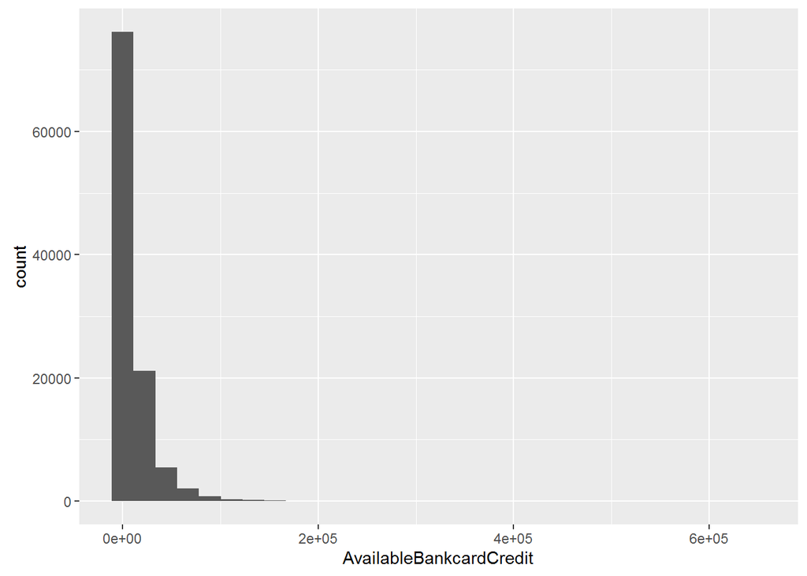

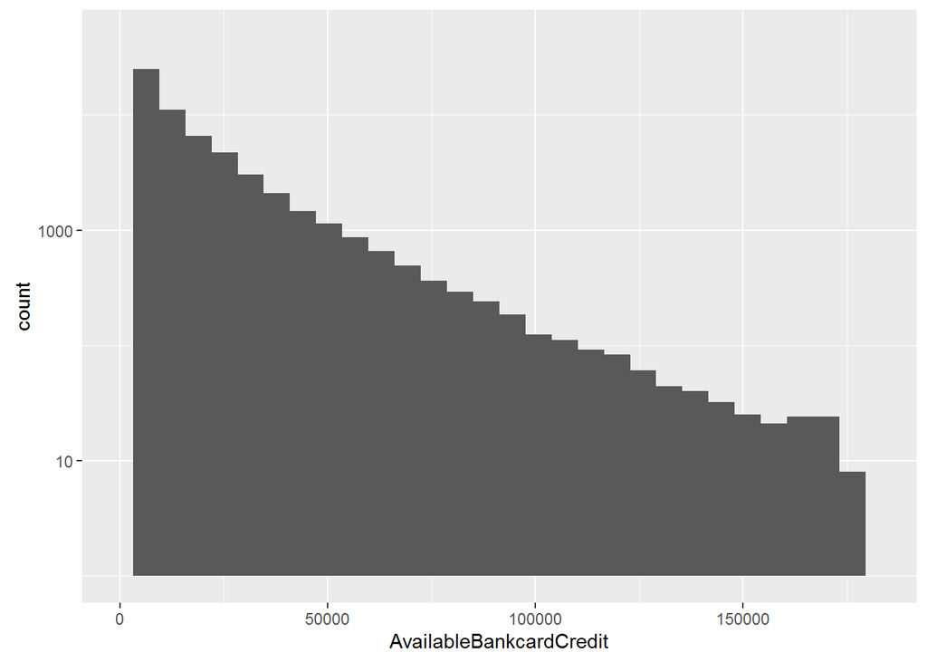

Notice that count of AvailableBankCredit decreases almost exponentially as the value increases.

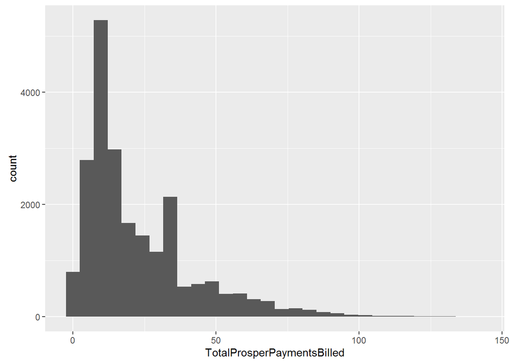

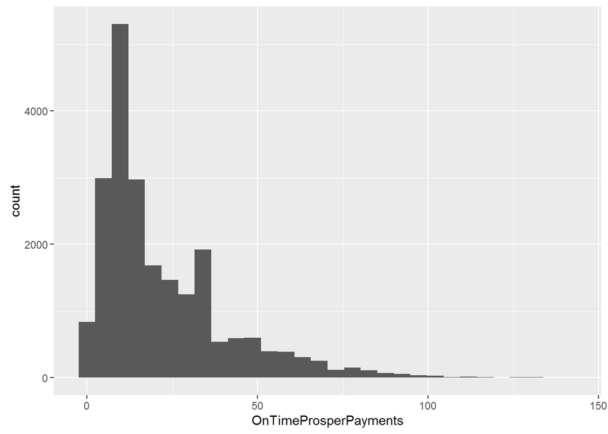

Above two graphs are quite similar

```
##
##  Pearson's product-moment correlation
##
## data:  TotalProsperPaymentsBilled and OnTimeProsperPayments
## t = 1059.4, df = 22083, p-value < 2.2e-16
## alternative hypothesis: true correlation is not equal to 0
## 95 percent confidence interval:
##  0.9900474 0.9905564
## sample estimates:
##       cor
## 0.9903052
```

High correlation indicates that fewer people pay late.

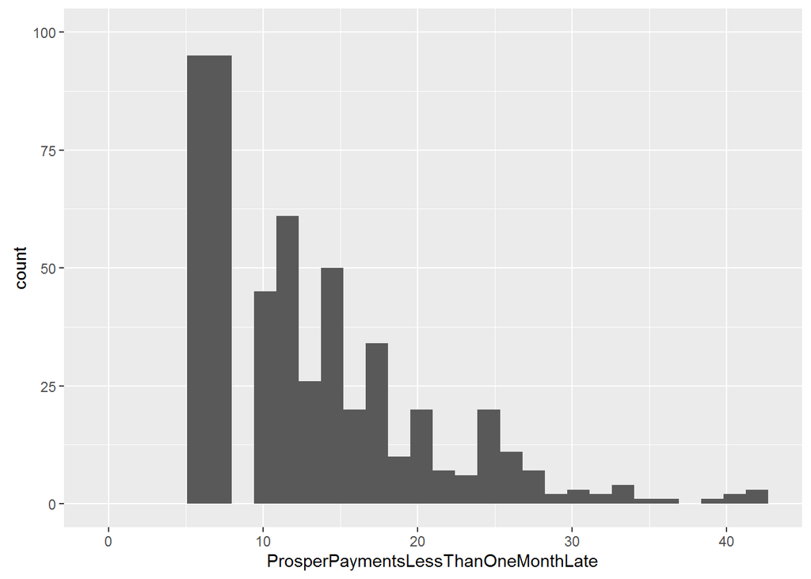

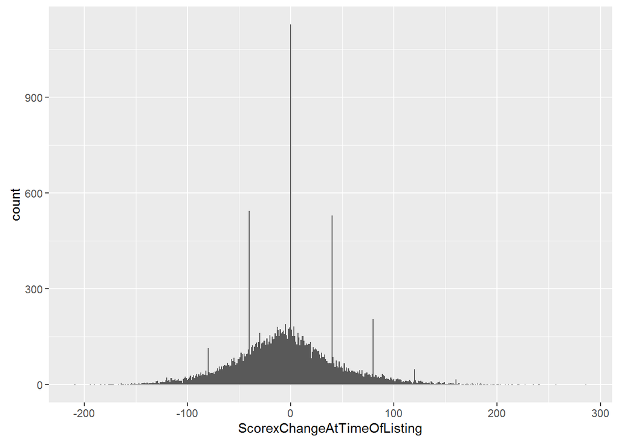

There are some extremely high counts for some of the scores.

```
## Source: local data frame [6 x 2]
##
##   ScorexChangeAtTimeOfListing     n
##                         (int) (int)
## 1                           0  1127
## 2                         -40   544
## 3                          40   529
## 4                          80   205
## 5                          -5   189
## 6                           3   182
```

0, +/-40, and +/-80 are the outliers.

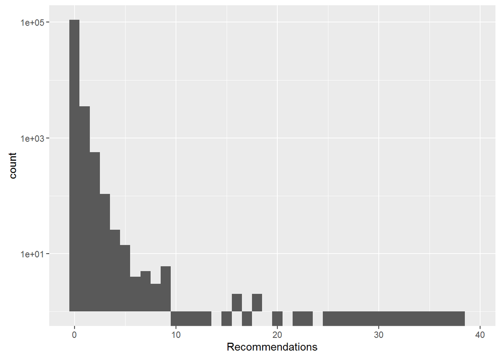

```
## Source: local data frame [17 x 3]
##
##    Recommendations     score      n
##              (int)     (dbl)  (int)
## 1                0  5.942179 109678
## 2                1  6.466019   3516
## 3                2  6.608974    568
## 4                3  6.318182    108
## 5                4  5.500000     26
## 6                5  8.000000     14
## 7                9  9.000000      6
## 8                7       NaN      5
## 9                6       NaN      4
## 10               8       NaN      3
## 11              16       NaN      2
## 12              18  9.500000      2
## 13              14       NaN      1
## 14              19 10.000000      1
## 15              21       NaN      1
## 16              24       NaN      1
## 17              39       NaN      1
```

```
##
##  Pearson's product-moment correlation
##
## data:  ProsperScore and Recommendations
## t = 7.7679, df = 84851, p-value = 8.069e-15
## alternative hypothesis: true correlation is not equal to 0
## 95 percent confidence interval:
##  0.01993270 0.03338005
## sample estimates:
##        cor
## 0.02665758
```

Some loans have comparatively high recommendations while most loans have no recommendation. Although by summarising, loans with more recommendations tend to have higher Prosper Scores, but corelation test tells us nothing. This may due to dominantly high count of zero recommendations.

## More Analysis

Firstly I will investigate the relationship between the nine similar distributed variables.

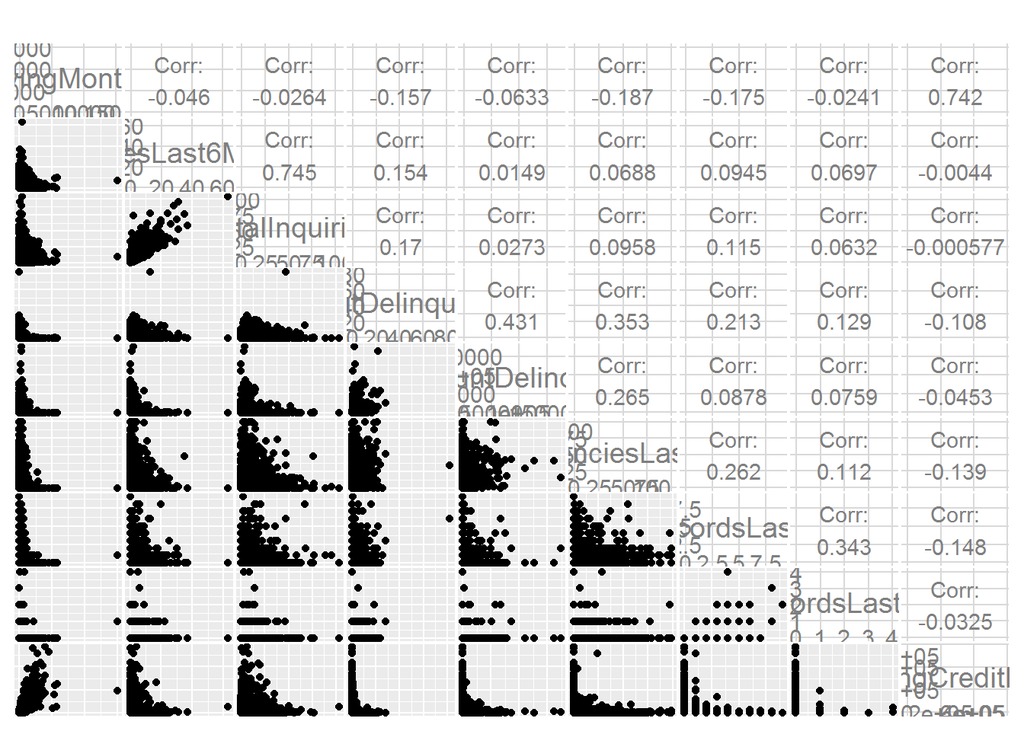

Also, notice that there are several different scores in the dataset: CreditGrade, ProsperRating, ProsperScore, ScorexChangeAtTimeOfListing.The four scores should agree with each other.

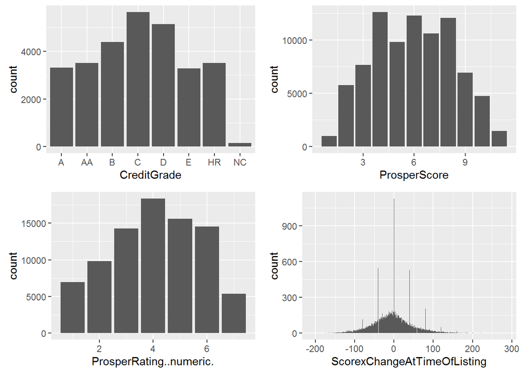

However, Graphs of the four scores are quite different.

A question then arises: What are these four scores?

According to [the discription document](https://docs.google.com/spreadsheets/d/1gDyi_L4UvIrLTEC6Wri5nbaMmkGmLQBk-Yx3z0XDEtI/edit#gid=0), CreditGrade was the credit rating before 2009, and ProsperScore/ProsperRating was the credit rating after July 2009. The ScorexChangeAtTimeOfListing is the change in score between each loan of a specific borrower.

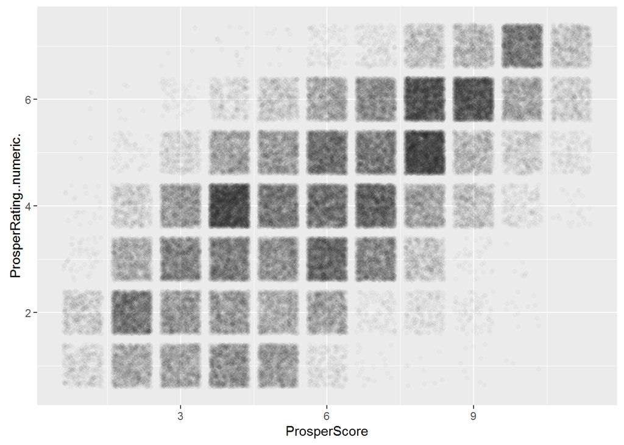

According to the graph, ProsperScore and ProsperRating agree with each other in trend, but disagree with each other in many profiles. Therefore a question arises: which score is more reliable?

```
##    score avg_delinq
## 1      1 4571.74212
## 2      2 2095.93068
## 3      3 2196.54025
## 4      4 2076.32445
## 5      5 1279.52795
## 6      6 1487.15213
## 7      7 1356.45065
## 8      8  901.13562
## 9      9  720.16092
## 10    10   34.04785
```

```
##   rating avg_delinq
## 1      1 2686.89691
## 2      2 2165.93915
## 3      3 1662.44313
## 4      4 1211.52976
## 5      5 1098.59173
## 6      6  926.84200
## 7      7   39.59009
```

Both the Score and the Rating are reliable in the sense that people with highest scores/ratings have least average delinquencies in the ‘future’, and people with lowest scores/ratings have most average delinquencies in the ‘future’.

However, average delinquency of people with higher ratings is lower than that of people with lower ratings, while average delinquencies of people with some scores (<2,3,4>,<5,6,7>) are approximately the same.

Therefore, the rating might be a more appropriate measure of people’s credit.

The next question is: what kinds of profiles tend to have a higher rating?

The following variables may relate to the ProsperRating:

EstimatedReturn, ListingCategory, Occupation, EmploymentStatusDuration, IsBorrowerHomeowner, GroupKey, DelinquenciesLast7Years, PublicRecordsLast12Months, IncomeVerifiable, OnTimeProsperPayments, ProsperPaymentsOneMonthPlusLate, Recommendations

Effect of them will be investigated separately.

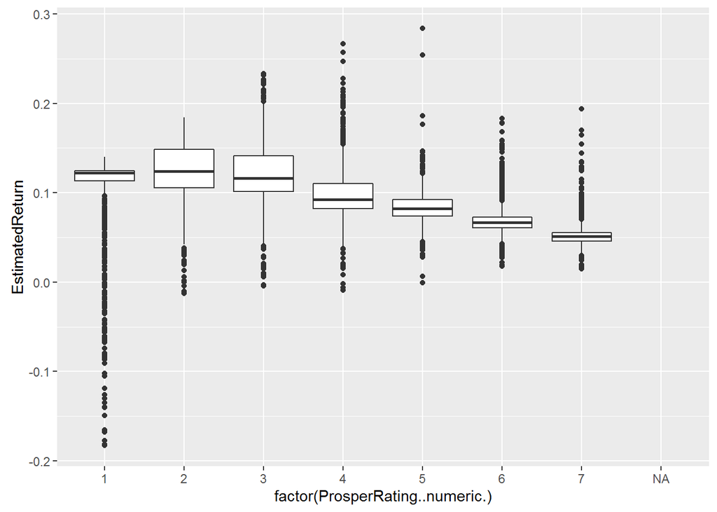

```
##
##  Pearson's product-moment correlation
##
## data:  ProsperRating..numeric. and ListingCategory..numeric.
## t = -27.643, df = 84851, p-value < 2.2e-16
## alternative hypothesis: true correlation is not equal to 0
## 95 percent confidence interval:
##  -0.1011382 -0.0878014
## sample estimates:
##         cor
## -0.09447405
```

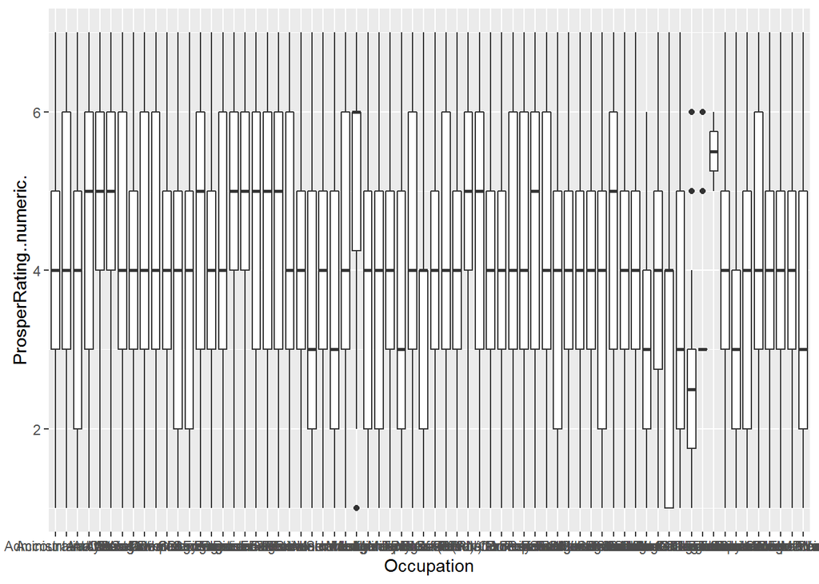

```
##
##  Pearson's product-moment correlation
##
## data:  ProsperRating..numeric. and EmploymentStatusDuration
## t = 10.513, df = 84832, p-value < 2.2e-16
## alternative hypothesis: true correlation is not equal to 0
## 95 percent confidence interval:
##  0.02935097 0.04279189
## sample estimates:
##        cor
## 0.03607306
```

```
##   rating avg_employment_dur
## 1      1           94.51471
## 2      2           97.15202
## 3      3           98.94933
## 4      4          106.19471
## 5      5          108.49053
## 6      6          105.77105
## 7      7          101.90989
```

```
##
##  Wilcoxon rank sum test with continuity correction
##
## data:  subset(data_o, !is.na(ProsperRating..numeric.) & IsBorrowerHomeowner ==  and subset(data_o, !is.na(ProsperRating..numeric.) & IsBorrowerHomeowner ==     "True")$ProsperRating..numeric. and     "False")$ProsperRating..numeric.
## W = 1040500000, p-value < 2.2e-16
## alternative hypothesis: true location shift is greater than 0
```

```
##                     GroupKey    avg_rating          n
##  07033365584575590A45181: 1   Min.   :2.774   Min.   : 10.00
##  18DA336463918236939DCE7: 1   1st Qu.:3.365   1st Qu.: 14.00
##  19F2338715202723004007F: 1   Median :3.600   Median : 24.00
##  2AC1336501013971385DB0A: 1   Mean   :3.771   Mean   : 49.74
##  3D4D3366260257624AB272D: 1   3rd Qu.:4.256   3rd Qu.: 70.50
##  4707336438924330015F446: 1   Max.   :4.909   Max.   :310.00
##  (Other)                :25
```

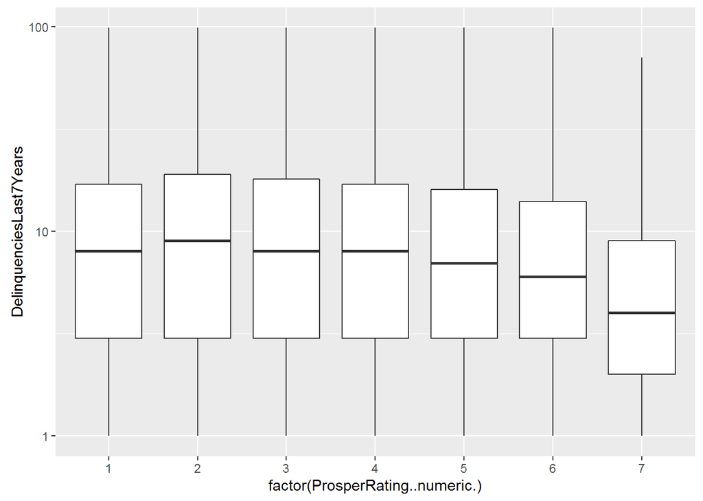

```
##
##  Pearson's product-moment correlation
##
## data:  ProsperRating..numeric. and DelinquenciesLast7Years
## t = -43.335, df = 84851, p-value < 2.2e-16
## alternative hypothesis: true correlation is not equal to 0
## 95 percent confidence interval:
##  -0.1537256 -0.1405600
## sample estimates:
##        cor
## -0.1471493
```

```
##
##  Wilcoxon rank sum test with continuity correction
##
## data:  subset(data_o, !is.na(ProsperRating..numeric.) & PublicRecordsLast12Months ==  and subset(data_o, !is.na(ProsperRating..numeric.) & PublicRecordsLast12Months !=     0)$ProsperRating..numeric. and     0)$ProsperRating..numeric.
## W = 36983000, p-value < 2.2e-16
## alternative hypothesis: true location shift is greater than 0
```

```
##
##  Wilcoxon rank sum test with continuity correction
##
## data:  subset(data_o, !is.na(ProsperRating..numeric.) & IncomeVerifiable ==  and subset(data_o, !is.na(ProsperRating..numeric.) & IncomeVerifiable ==     "True")$ProsperRating..numeric. and     "False")$ProsperRating..numeric.
## W = 349250000, p-value < 2.2e-16
## alternative hypothesis: true location shift is greater than 0
```

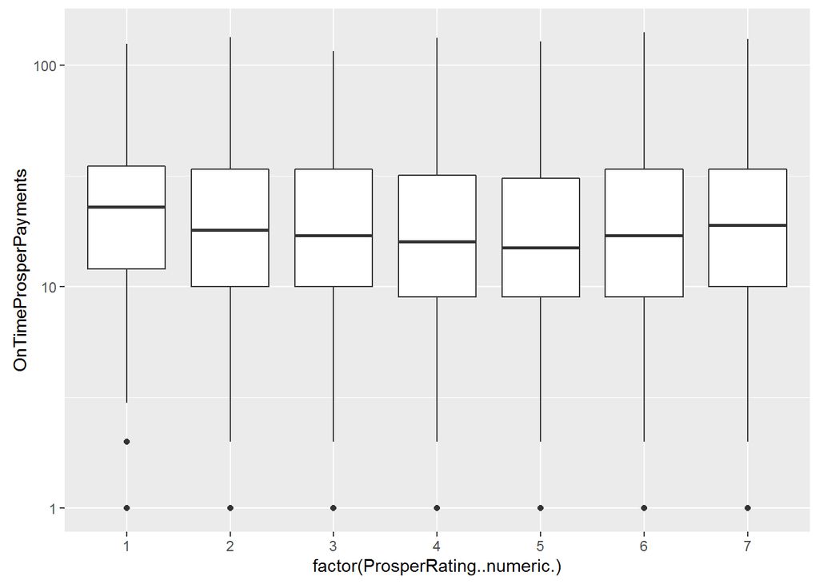

```
##
##  Pearson's product-moment correlation
##
## data:  ProsperRating..numeric. and OnTimeProsperPayments
## t = -2.3552, df = 19795, p-value = 0.01852
## alternative hypothesis: true correlation is not equal to 0
## 95 percent confidence interval:
##  -0.030660388 -0.002808056
## sample estimates:
##         cor
## -0.01673747
```

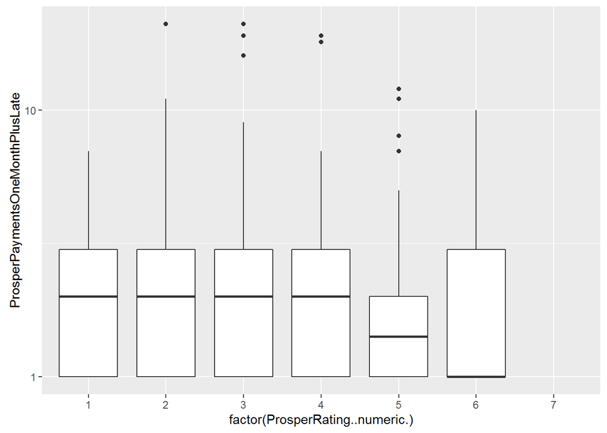

```
##
##  Pearson's product-moment correlation
##
## data:  ProsperRating..numeric. and ProsperPaymentsOneMonthPlusLate
## t = -7.162, df = 19795, p-value = 8.227e-13
## alternative hypothesis: true correlation is not equal to 0
## 95 percent confidence interval:
##  -0.06472328 -0.03693514
## sample estimates:
##         cor
## -0.05083905
```

```
##
##  Wilcoxon rank sum test with continuity correction
##
## data:  subset(data_o, !is.na(ProsperRating..numeric.) & Recommendations !=  and subset(data_o, !is.na(ProsperRating..numeric.) & Recommendations ==     0)$ProsperRating..numeric. and     0)$ProsperRating..numeric.
## W = 5.1e+07, p-value = 0.4296
## alternative hypothesis: true location shift is greater than 0
```

EstimatedReturn, IncomeVerifiable and IsBorrowerHomeowner are directly related to the rating;

Some Occupations have different mean and variance than others, but may due to the small sample size;

Mean Employement Duration of all users are approximately the same. although those who are rated 1, 2, and 3 have approximately 10% lower values than those who are rated 4, 5, and 6, those who are rated 7 have average employment duartion between the two groups;

GroupKey may have correlation with average rating, but there are just too many group keys, so it is difficult to make a conclution about it;

DelinquentLast7Years has no strong correlation with ratings, but those who are rated 7 have significantly lower deliquencies;

Those who have PublicRecordsLast12Months equal to zero have higher average ratings by wilcox test;